# Time-Series Analysis of Paleoclimate Signals – Practical 03

Basics on StratigrapheR  
Coldigiocco Cyclonet Summer School 2025  
by C. Zeeden, M. Crucifix, A.C. Da Silva

Author

Anne-Christine Da Silva (with the support of S. Wouters & P. Cerfontaine)

Published

August 11, 2025

# StratiprapheR

Stratigrapher allows you to build lithologs and to plot your log on the side of your proxies and of your spectral analysis results (Wouters, Sébastien and Smith 2018; Wouters et al. 2021).

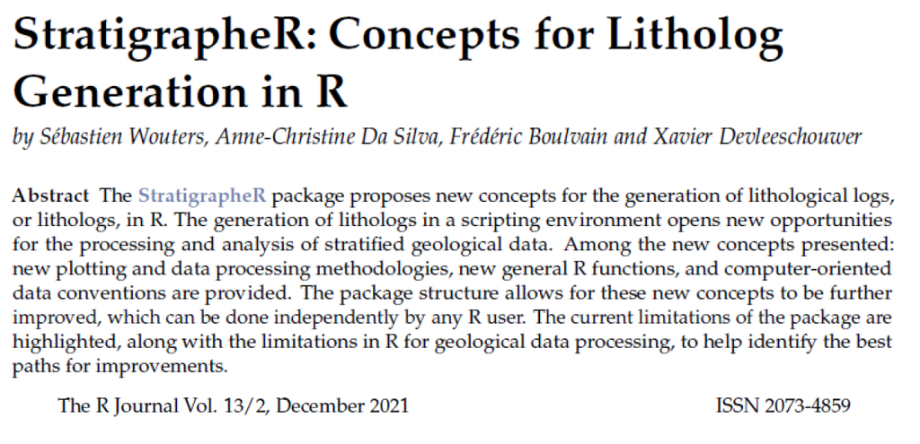

StratigrapheR - how to cite it

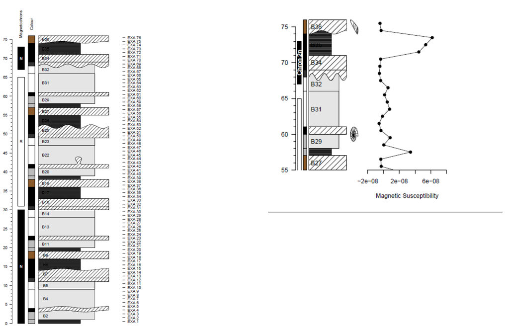

StratigrapheR - Stratigrapher plotting with magnetochron, color, sample position and another example with specific fossils on the side and magnetic susceptibility evolution.

For further features, type ?StratigapheR, you will have a complete script which includes most functions of StratigrapheR.

## StratigrapheR loading and dataframe structure

```r
library(StratigrapheR)

# and we also load a very useful package, used here for joining data frames
library(dplyr)
```

**Tip on the dataset needed to build a litholog in StratigrapheR**

Bed dataset —-

this dataset should include the description of each bed with :

- l - the position of the base of each bed (in cm or m) - l stands for the left side or boundary of an interval-

- r - the position of the top of each bed (in cm or m) - r stands for the right side or boundary of an interval-

- litho - the lithology, basics are for instance C for chert, S for shale, L for limestone… but you can include anything you want in any way you want

- h - relief or hardness of each bed

- id - is the bed identification, number (e.g. B1, B2, …)

you can also include other columns with anything else you find useful for each bed such as color or lithofacies

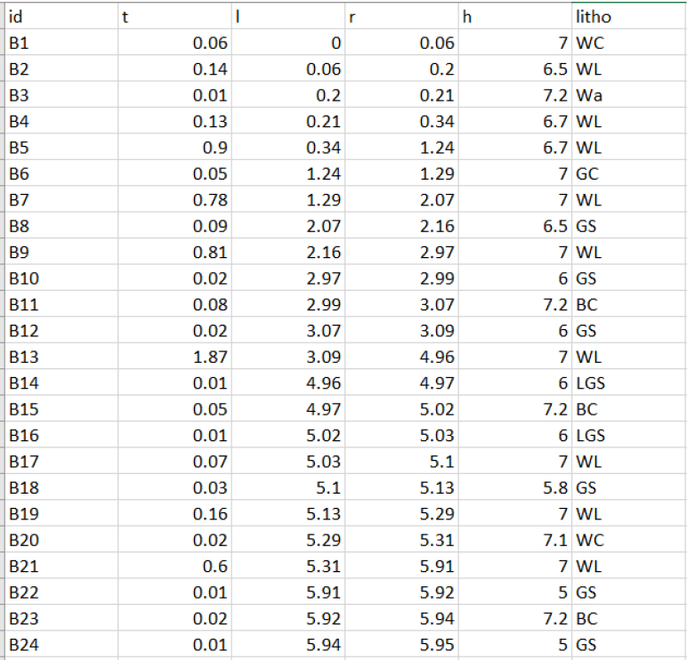

Structure of the dataframe to build a litholog in StratigrapheR

## Building a litholog

```r
# You may want to change your working directory for this, the example will generate .pdf and .txt files;
# setwd()
setwd("C:/Users/Anne-Christine/Documents/ANNECHRI2/POST/UTRECHT/Spectral ANALYSIS/StratigrapheR" )


# Once we have created our file we import our data
Log <- read.csv("log_entier_8.csv")

# StratigrapheR will take the basic data (l, r, h, id)

basic.log <- litholog(l = Log$l, r = Log$r, h = Log$h, i = Log$id)

# then we define the legend for each lithology ----

# for each lithology you can provide a color (col), a density of shading (density) and orientation for the lines (angle)

legend.Ch <- data.frame(litho = c("StC","S","DS","BS","StS", "CSt", "C", "M"),
                        col = c("burlywood", "bisque4", "grey40", "grey20", "antiquewhite3", "darkslategray", "azure2", "azure4"),
                        density = c(0,10,20,10,0,  10, 0,0),
                        angle = c(45, 180,180,180,180, 90, 0,0), stringsAsFactors = FALSE)

bed.legend <- left_join(Log,legend.Ch, by = "litho")

# Prepare plot title("M")
whiteSet(xlim = c(0,6), ylim = c(0,52), ytick = 5, ny = 5)

# Then, we add the polygons making the litholog. This is done with a single function identifying each polygon by the id of points. The graphical parameters of the polygons can be adapted to fit the legend, polygon by polygon.

multigons(basic.log$i, x = basic.log$xy, y = basic.log$dt,
          col = bed.legend$col, density = bed.legend$density,
          angle = bed.legend$angle)
```

## Creating a lithological curve evolution out of our litholog dataframe from the hardness profile.

```r
# We can Create a record from the hardness profile ----------------

# We create a vector of evenly spaced values between min and max depth values

# You can define the sampling rate if you modify the parameter "by = 0.02" with the interpolation you want.

sampling <- seq(from = min(Log$l), to = max(Log$r),
                by = 0.02)

hardness <- vector(mode = "numeric", length = length(sampling))

# extract hardness values from the sorted file data according to sampling depth

index <- 1
for( i in 1:(length(sampling)) )
  {
  if( sampling[i] > Log$r[index] )
    index <- index + 1
  hardness[i] = Log$h[index]
  }

# at this point just check that the index value should point to the end of the file because it should

stopifnot(index == nrow(Log))

h<- cbind(sampling, hardness)
hard<-as.data.frame(h)
plot(hard, type='l')
```

## Creating a lithological curve evolution out of our litholog dataframe from the facies profile.

```r
# We can Create a record from the facies evolution ----------------

# we create a new column (called lithonumber), the code name for each facies is replaced by a facies number

lithtonum = c("StC"=4,"S"=2,"DS"=1.5,"BS"=1,"StS"=2.2, "CSt"=4, "C"=4, "M"=3)

for ( litho_name in names(lithtonum)) {
  Log$lithonumber[Log$litho == litho_name] = lithtonum[litho_name] }

if( is.unsorted(Log$r, strictly = FALSE) )
  Log <- Log[order(Log$r),]

# create a vector of evenly spaced values between min and max depth values

# to replace sampling rate, replace by = 0.02 by the interpolation you want.

sampling <- seq(from = min(Log$l), to = max(Log$r), by = 0.02)

facies <- vector(mode = "numeric", length = length(sampling))

# extract facies values from the sorted file data according to sampling depth

index <- 1
for( i in 1:(length(sampling)) ) {
  if( sampling[i] > Log$r[index] )
    index <- index + 1
  facies[i] = Log$lithonumber[index]
}

# at this point just check that the index value should point to the end of the file because it should

stopifnot(index == nrow(Log))

f<- cbind(sampling, facies)
facies<-as.data.frame(f)
plot(facies, type='l')
```

## Plotting litholog with proxy

```r
#First we create a matrix with 3 column, one for our log, one for hardness and one for facies
layout(matrix(c(1, 2, 3),
              nrow = 1,
              ncol = 3),
       heights = c(1),          # Heights of the row
       widths = c(1, 1, 1))     # Width of the columns
par(yaxs="i")
# set the y axis (if you want to see the whole record or to zoom on some part, you can change that here)
ylim=c(0,52)
# here you can set the graduations
ytick = 1

# we create the first column, through "par" we set the size of the margins: c(bottom, left, top, right)
par(mar=c(2, 1, 2, 0.2))
whiteSet(xlim = c(0, 6), ylim = ylim, ytick = ytick, ny = 1) # Prepare plot
multigons(basic.log$i, x = basic.log$xy, y = basic.log$dt,
          col = bed.legend$col,
          density = bed.legend$density,
          angle = bed.legend$angle) # include log

# we create the second column
par(mar=c(2, 1, 2, 0.2))
plot(hard$hardness, hard$sampling, type='l', col='darkblue', axes=FALSE, frame.plot=TRUE, ylim=ylim)
axis(side=1)
Axis(side=2, labels=FALSE, tick=FALSE, line=FALSE)
legend("bottomleft", "Hardness", cex=1.5, bty="n", text.col = "black")

# we create the third column
par(mar=c(2, 1, 2, 0.2))
plot(facies$facies, facies$sampling, type='l', col='darkgreen', axes=FALSE, frame.plot=TRUE, ylim=ylim)
axis(side=1)
Axis(side=2, labels=FALSE, tick=FALSE, line=FALSE)
legend("bottomright", "Facies", cex=1.5, bty="n", text.col = "black")
```

## References

Wouters, S., A. C. Da Silva, F. Boulvain, and X. Devleeschouwer. 2021. “StratigrapheR: Concepts for Litholog Generation in R.” *R Journal* 13 (2): 153–78.

Wouters, Sébastien, and Adam D. Smith. 2018. “StratigrapheR: Integrated Stratigraphy.” Comprehensive R Archive Network. https://doi.org/10.32614/CRAN.package.StratigrapheR.